# TP2 stats

Romain PEREIRA

5 Mars 2018

# 1. Echantillon, Théorème Central Limite, Estimation Monte Carlo

### 1.1 Simulation de 1000 échantillon i.i.d gaussien.

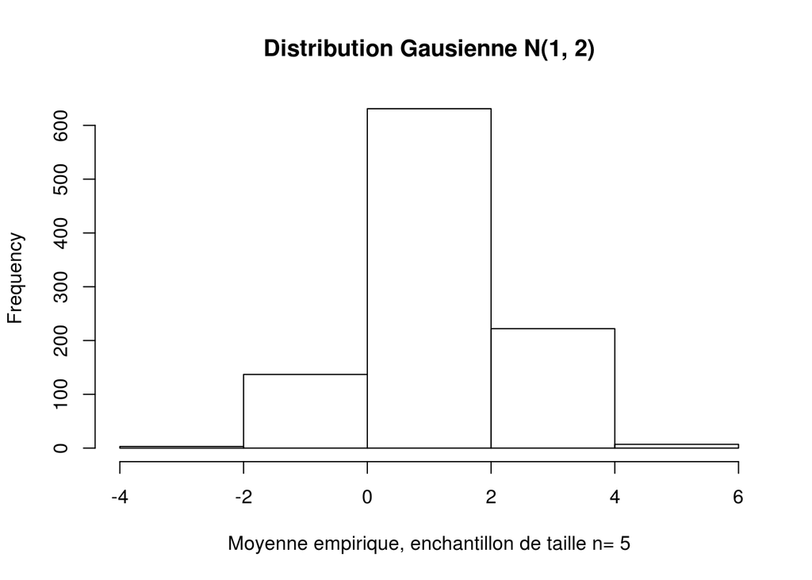

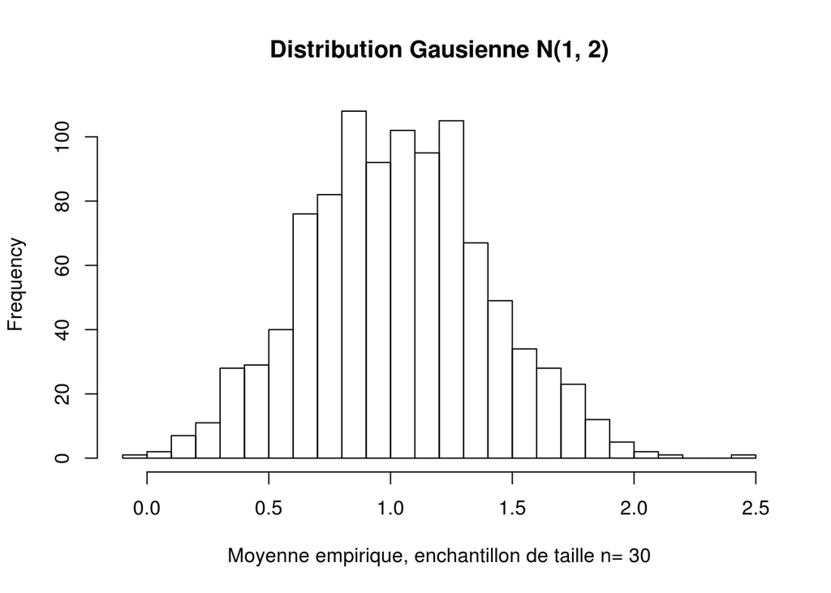

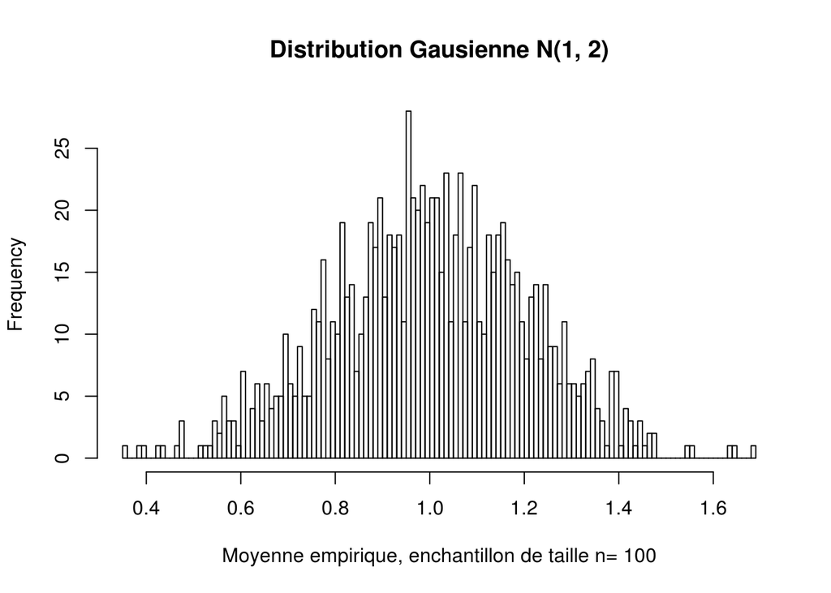

```r
N <- 1000
n <- c(5, 30, 100)

empirical_mean <- function(vec) {
  s <- 0
  for (x in vec) {
    s <- s + x
  }
  return (s / (length(vec) - 1))
}

empirical_var <- function(vec) {
  m <- empirical_mean(vec)
  s <- 0
  for (x in vec) {
    s <- s + (x - m) * (x - m)
  }
  return (s / (length(vec) - 1))
}

# fonction 'mean_hist'
#
# 'law' : fonction qui genere un vecteur de taille 'm', e.g: law(42)
# 'title': titre de l'histogramme
#
# La fonction trace 3 histogrammes de la loi de la moyenne empirique
# sur 'N' echantillons de taille dans 'ns'
mean_hist <- function(law, title) {
  for (nj in n) {
    sample <- law(nj * N)
    means <- c()
    for (i in 1:N) {
      subsample <- sample[((i-1)*nj + 1): (i * nj)]
      Xni <- empirical_mean(subsample)
      # vni <- empirical_var(subsample)
      means <- c(means, Xni)
    }
    hist(means, xlab=paste("Moyenne empirique, enchantillon de taille n=", nj), main=title, breaks=nj)
  }
}

mean_hist(function(n) { return (rnorm(n, mean=1, sd=2)) }, "Distribution Gausienne N(1, 2)")
```

Je pose $S_n = \sum_{i=1}^{n}X_i$, tel que:: + les $X_i$ i.i.d de même loi + $E[X_i] = \mu$ + $\mathbb{V}[X_i]=\sigma^2$.

D’après le théorème central limite, pour $N$ assez grand, $S_n$ suit approximativement une loi normal ${N}(n\mu, n\sigma^2)$.

En notant la moyenne empirique $\bar X_n = \frac{S_n}{n}$, on a:

$\mathbb{E}[\bar X_n] = \mathbb{E}[\frac{S_n}{n}] = \frac{1}{n}\mathbb{E}[S_n] = \mu$

$\mathbb{E}[\bar X_n] = \mathbb{V}[\frac{S_n}{n}] = \frac{1}{n^2}\mathbb{V}[S_n] = \frac{\sigma^2}{n}$

Dans notre exemple, les $X_i$ suivent une loi $N(1, 2)$.

En notant $(a_n, b_n) = (\text{moyenne}, \text{ecart-type}) = (\mu, \sqrt\frac{\sigma^2}{n}) = (1, \frac{2}{\sqrt{n}})$, $U_n = \frac{\bar{X_n} - a_n}{b_n}$ suit une loi normal centrée réduite $N(0, 1)$.

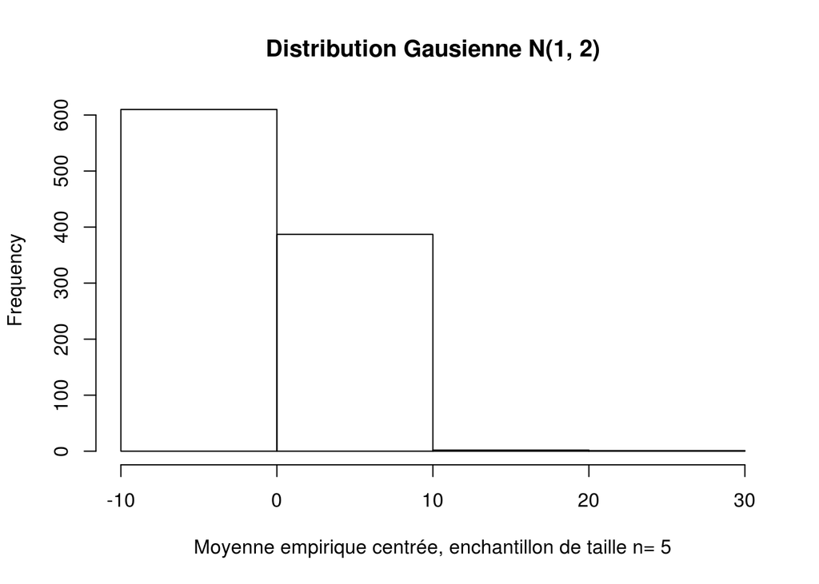

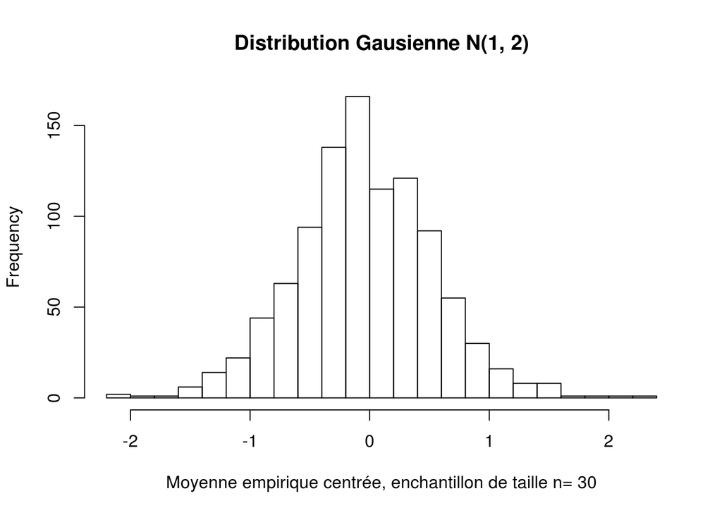

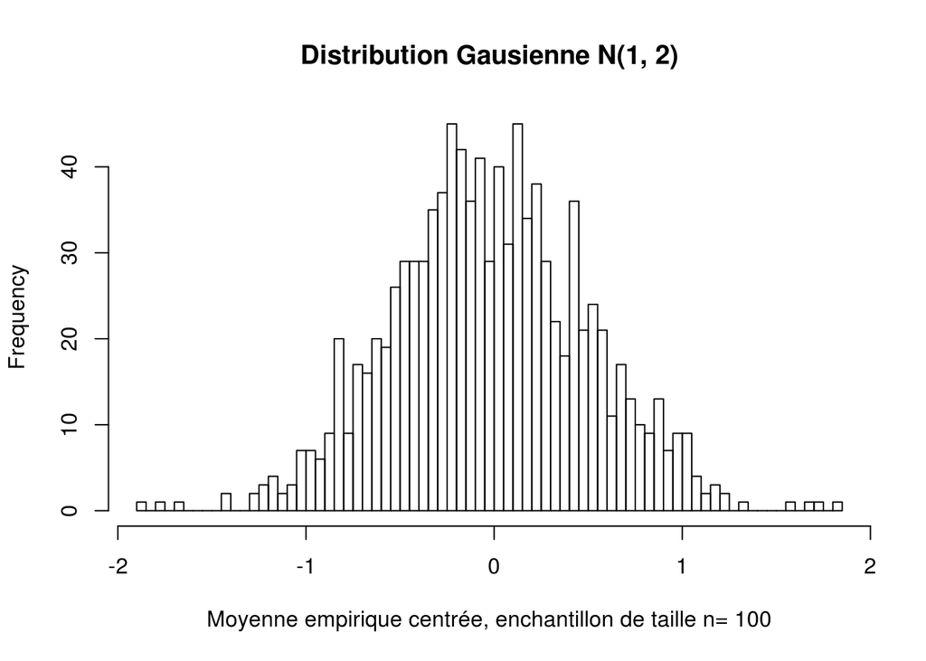

```r
# fonction 'mean_norm_hist'
#
# 'law' : fonction qui genere un vecteur de taille 'm', e.g: law(42)
# 'title': titre de l'histogramme
#
# La fonction trace 3 histogrammes de la loi de la moyenne empirique renormalisé
# sur 'N' echantillons de taille dans 'ns'
mean_norm_hist <- function(law, title) {
  for (nj in n) {
    sample <- law(nj * N)
    Xn <- empirical_mean(sample)
    Un <- c()
    for (i in 1:N) {
      subsample <- sample[((i-1)*nj + 1): (i * nj)]
      ani       <- empirical_mean(subsample)
      bni       <- empirical_var(subsample) / sqrt(nj)
      Uni       <- (Xn - ani) / bni
      Un        <- c(Un, Uni)
    }
    hist(Un, xlab=paste("Moyenne empirique centrée, enchantillon de taille n=", nj), main=title, breaks=nj)
  }
}

mean_norm_hist(function(n) { return (rnorm(n, mean=1, sd=2)) }, "Distribution Gausienne N(1, 2)")
```

### 1.2 Loi de Pareto

Soit $X$ une variable aléatoire suivant une loi de Pareto $P(a, \alpha), \alpha > 2$. Alors, $\mathbb{E}[X]=\frac{\alpha a}{\alpha - 1}$ et $\mathbb{V}[X]=(\frac{\alpha a}{\alpha - 1})^2\frac{\alpha}{\alpha - 2}$

```r
library("rmutil")
```

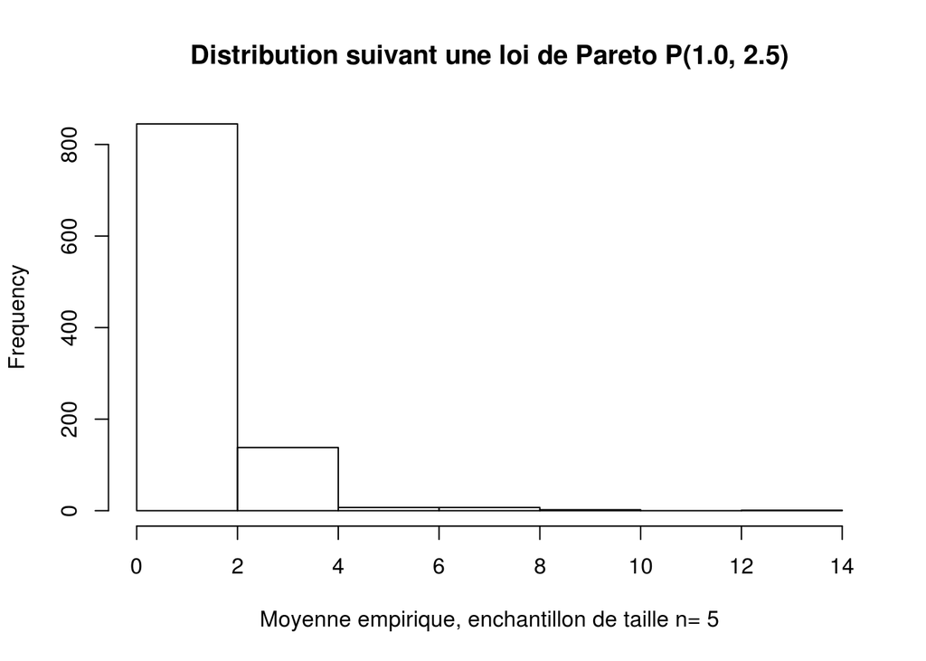

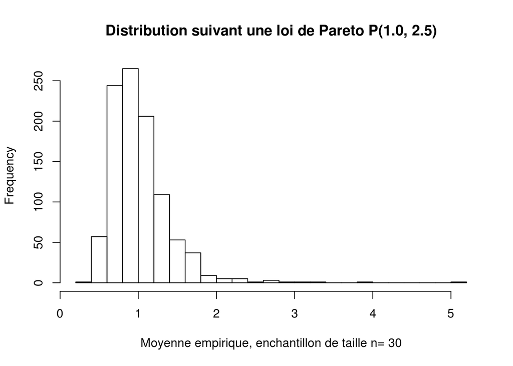

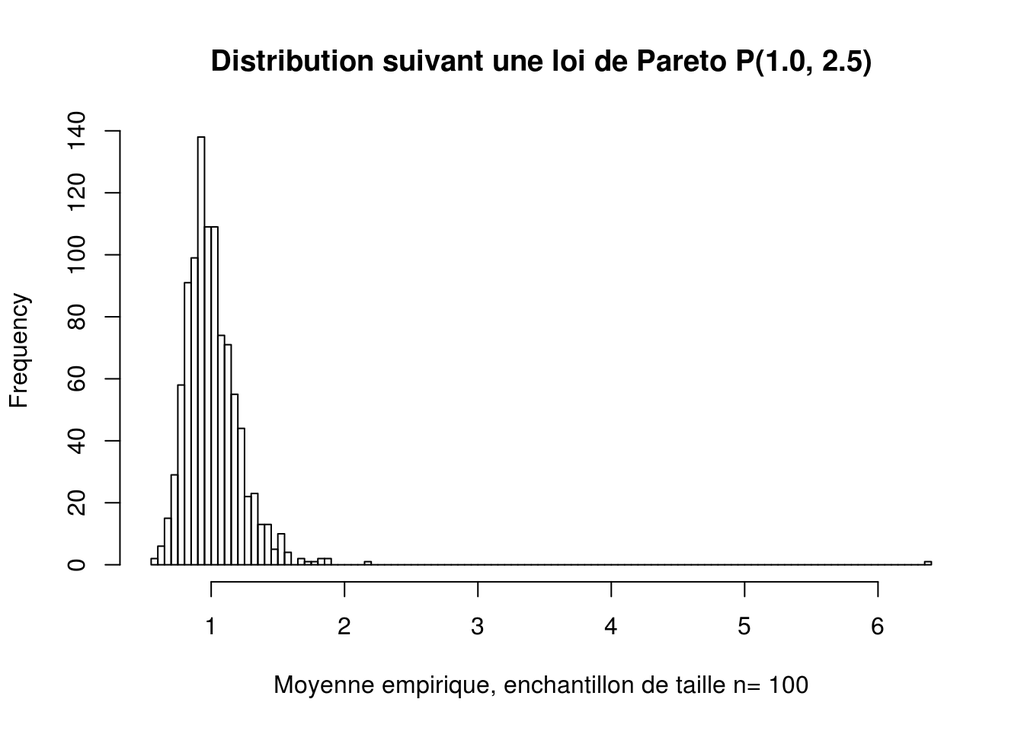

```r
a     <- 1.0
alpha <- 2.5
mean_hist(function(n) { return (rpareto(n, m=a, s=alpha)) }, "Distribution suivant une loi de Pareto P(1.0, 2.5)")
```

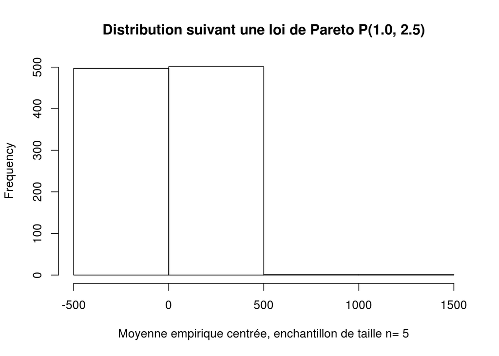

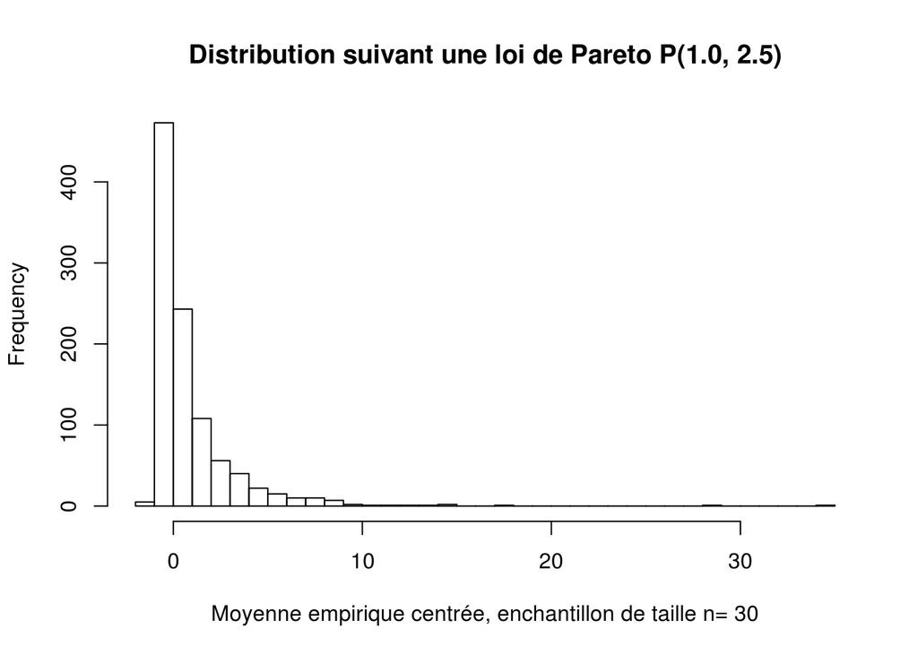

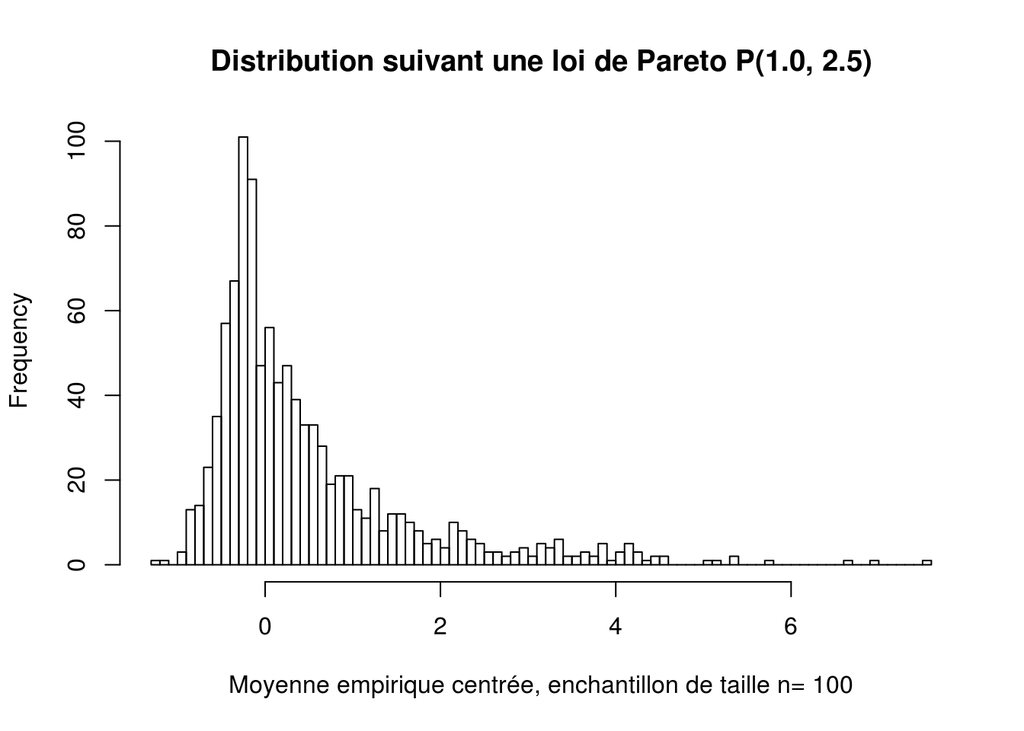

```r
mean_norm_hist(function(n) { return (rpareto(n, m=a, s=alpha)) }, "Distribution suivant une loi de Pareto P(1.0, 2.5)")
```

### 1.3 Loi de Poisson

Soit $X$ une variable aléatoire suivant une loi de Poisson $P(\lambda)$. Alors, $\mathbb{E}[X]=\lambda$ et $\mathbb{V}[X]=\lambda$

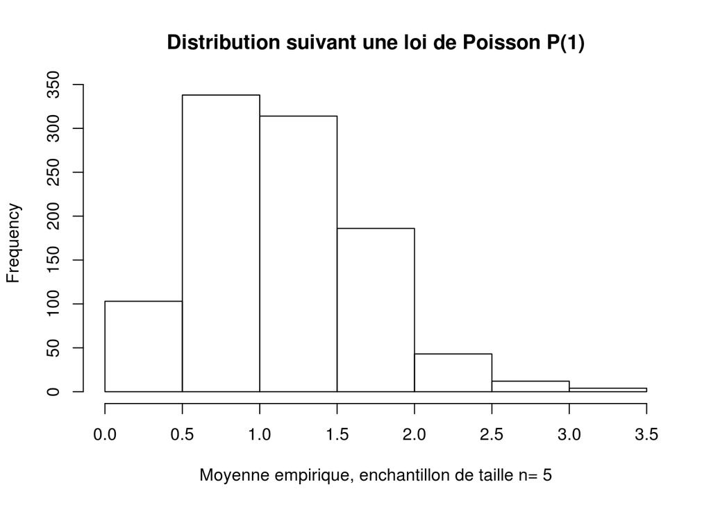

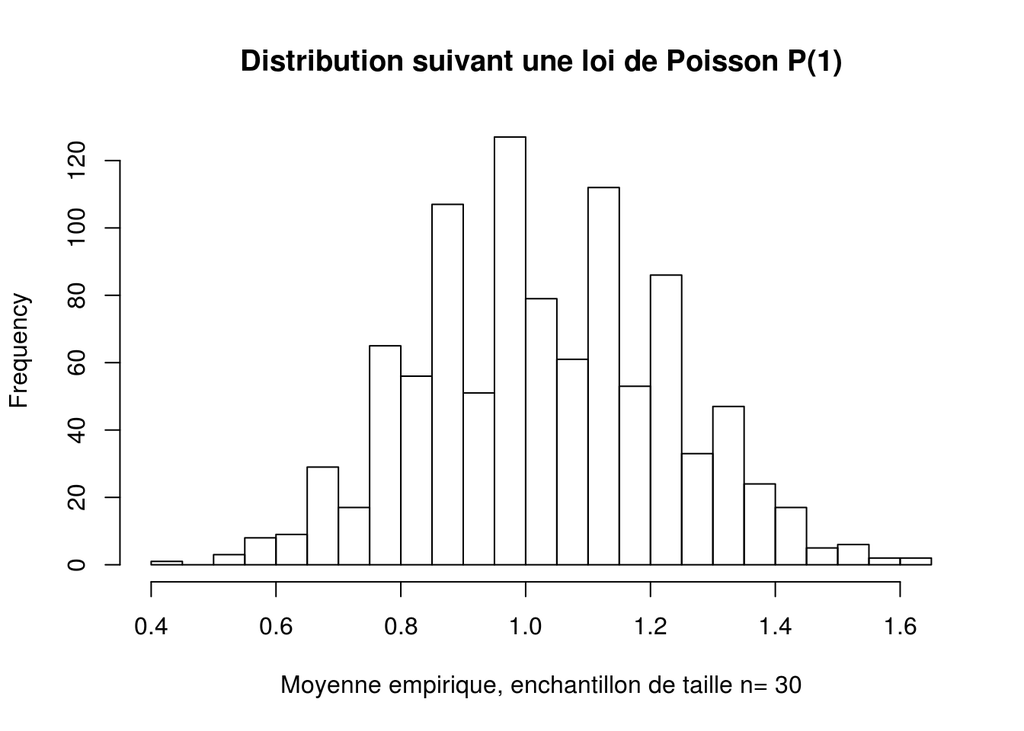

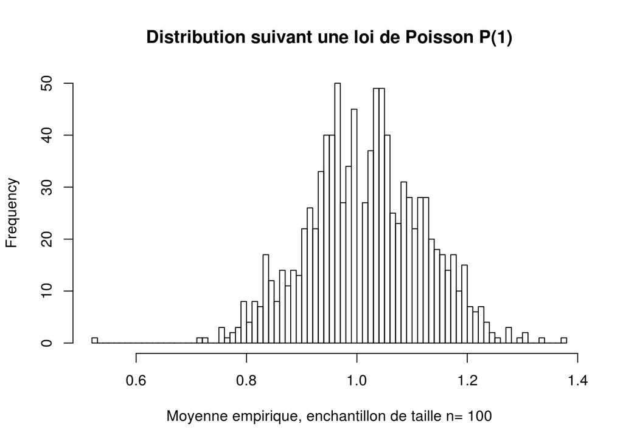

```r
mean_hist(function(n) { return (rpois(n, lambda=1)) }, "Distribution suivant une loi de Poisson P(1)")
```

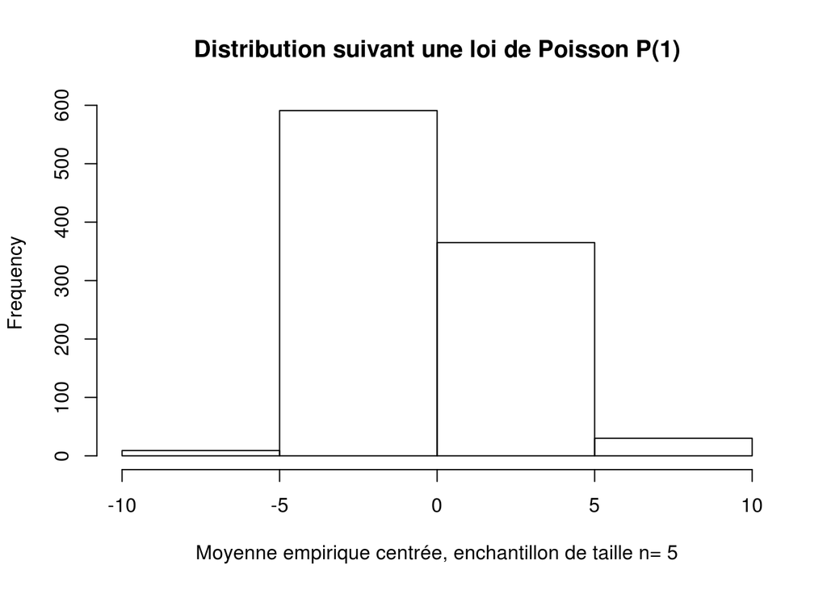

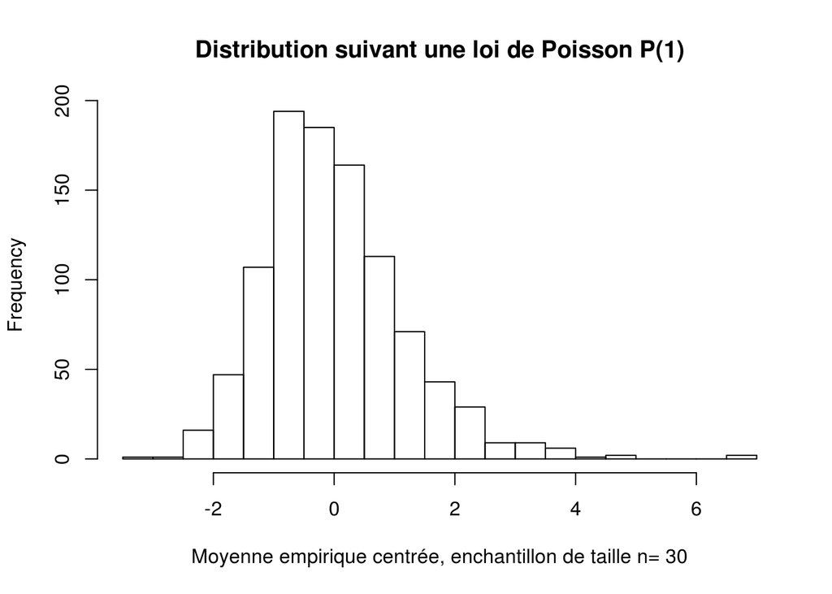

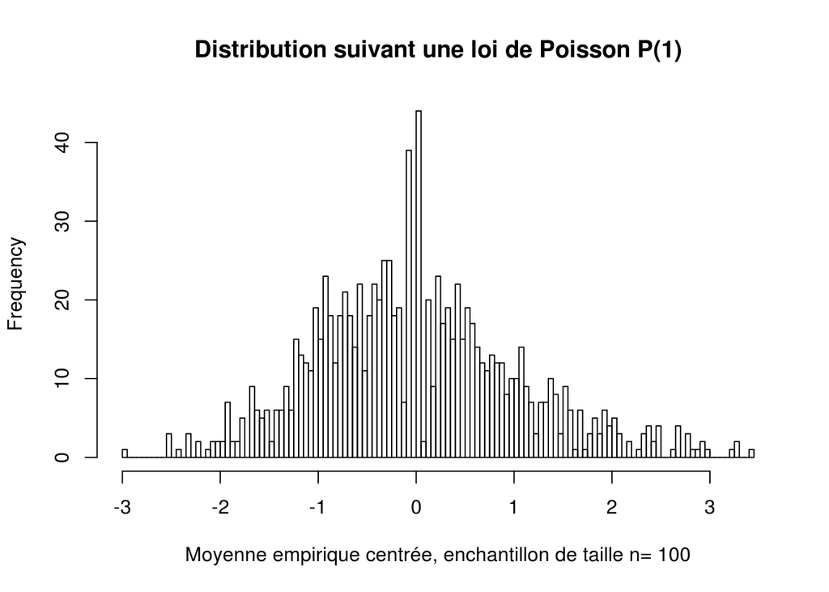

```r
mean_norm_hist(function(n) { return (rpois(n, lambda=1)) }, "Distribution suivant une loi de Poisson P(1)")
```

De même, plus $n$ est grand, plus la loi moyenne empirique renormalisé semble suivre une loi N(0, 1).

### 1.4 Méthode d’expérimentation

On note $X=(X_1, ..., X_n)$ pour $n \in \mathbb{R}$, un échantillon de taille $n$ (simulable ‘facilement’)

On suppose que tous les $X_i$ son i.i.d, et suivent la même loi.

Soit $T : \Omega^n \rightarrow \mathbb{R}$ une statistique sur un echantillon de taille $n$.

On peut trouver une approximation de l’espérance $\mathbb{E}[T(X)]$ en utilisant le protocole suivant:

1. Fixer $N \in \mathbb{N}, N \gg 1$.
2. Générer $N$ échantillons de taille $n$, notés $X^i = (X^i_1, ..., X^i_n)$ avec $1 \leq i \leq N$
3. Je pose
- $\bar T_N = \frac{1}{N}\sum_{i=1}^{N}{T(X^i)}$
- Lorsque $N$ devient grand, d’après le théorème central limite (même raisonnement qu’en $\textbf{1.1}$):
  - $(1)$ : $\mathbb{E}[\bar T_N] \xrightarrow[N \gg 1]{} \mathbb{E}[T(X)]$
  - $(2)$ : $\mathbb{V}[\bar T_N] \xrightarrow[N \gg 1]{} \frac{1}{N}\mathbb{V}[T(X)] \xrightarrow[N \rightarrow +\infty]{} 0$
4. Donc d’après $(1)$ et $(2)$, on a $\bar T_n{\xrightarrow[N \rightarrow +\infty]{\mathbb {L} ^{2}} \mathbb{E}[T(X)] = cste}$.

Autrement dit, la moyenne empirique (entant que variable aléatoire), tends (en norme 2) vers la v.a constante $\mathbb{E}[T(X)]$.

La moyenne empirique est une bonne estimation de l’espérance quand elle est effectué sur un grand nombre d’échantillon.

# 2. Moyenne et dispersion.

### 2.1 Inégalité de Bienaymé Tchebychev

Soit X une variable aléatoire admettant un moment d’ordre 2 (et donc un moment d’ordre 1). L’inégalité de Bienaymé-Tchebychev affirme: $\forall \alpha \in \mathbb{R}^*_+, \mathbb{P}(|X-\mathbb{E}[X]| \geq \alpha) \leq \frac{1}{\alpha^2}\mathbb{V}[X]$

Pour une loi Gaussienne $N(\mu, \sigma^2)$, on a : $\mathbb{P}(|X-\mu| \geq \alpha) \leq \frac{\sigma^2}{\alpha^2}$

Pour une loi de Poisson $P(\lambda)$, on a : $\mathbb{P}(|X-\lambda| \geq \alpha) \leq \frac{\lambda}{\alpha^2}$

### 2.2 Estimation par Monte Carlo.

$(a)$ $\mathbb{P}(|X-\mu|\geq \delta) = \mathbb{E}[\mathbb{1}_{\{|X-\mu| \geq \delta\}}] = \mathbb{E}[Z]$, en posant $Z = \mathbb{1}_{\{|X-\mu| \geq \delta\}}$

$(b)$ On estime $\mathbb{E}[Z]$ par la moyenne empirique $\bar Z_N = \frac{1}{N}\sum_{i=1}^{N}{T(Z^i)}$ :

```r
# effectue une estimation de Monte Carlo sur une loi Gaussienne, de Pareto, et de Poisson.
#
# N : nombre d'echantillon pour la moyenne
# delta : verifiant (a)
# (mu, sigma) : paramètre de la loi Gausienne
# (a, alpha) : paramètre de la loi de Pareto
# (lambda) : paramètre de la loi de Poisson
#
# renvoie une liste contenant :
#           - les distributions générées
#           - la moyenne empirique de ces distributions
#           - les distributions transformées Z (voir (a))
#           - les espérances empirique de Z, approximation de (a)
estimate_monte_carlo <- function(N, delta, mu, sigma, a, alpha, lambda) {
  # On genere des distributions
  XN       <- list("Gauss" = rnorm(N, mu, sigma), "Pareto" = rpareto(N, a, alpha), "Poisson" = rpois(N, lambda))
  XN_means <- list("Gauss" = mu,                  "Pareto" = alpha*a/(alpha - 1),  "Poisson" = lambda)
  ZN       <- list()
  ZN_means <- list()
  # Pour chaque distributions
  for (distrib in names(XN)) {
    # on recupere la distribution
    XNi      <- XN[[distrib]]
    XNi_mean <- XN_means[[distrib]]
    # on génère la variable aléatoire Z correspondante
    ZN[[distrib]] <- unlist(lapply(XNi, function(xi) {
                              if (abs(xi-XNi_mean) >= delta) {
                                return (1)
                              }
                              return (0)
                            }))
    ZN_means[[distrib]] <- empirical_mean(ZN[[distrib]])
  }
    # on affiche E[Zi] = P[|Xi - mean| >= delta]
  return (list("XN" = XN, "XN_means" = XN_means, "ZN" = ZN, "ZN_means" = ZN_means));
}
```

On obtient selon les différentes lois: $\mathbb{P}(|X-\mathbb{E}[X]|\geq \delta_{=1} =\space ...$

```r
N <- 1e5
estimation <- estimate_monte_carlo(N, delta=1, mu=0, sigma=1, a=1.0, alpha=2.5, lambda=1)
estimation[["ZN_means"]]
```

```
## $Gauss
## [1] 0.3184632
##
## $Pareto
## [1] 0.6803468
##
## $Poisson
## [1] 0.6331063
```

La moyenne empirique est une variable aléatoire, et on a montré que $\mathbb{E}[\bar Z_N] = \mathbb{E}[Z]$ et une variance $\mathbb{V}[\bar Z_N] = \frac{1}{N}\mathbb{V}[Z]$.

Donc d’après le théorème de Bienaymé Tchebichev, la précision de notre estimation $\mathbb{P}(|X-\mu|\geq \delta) = \mathbb{E}[Z] \simeq \bar Z_N$, est donné par:

$\forall \epsilon \geq 0, \mathbb{P}[|\bar Z_N - \mathbb{E}[Z]| \geq \epsilon] \leq \frac{1}{\epsilon \space N}\mathbb{V}[Z]$.

$(c)$ Application numérique:

```r
markov_sup <- function(Z, N, eps) {
  return (var(Z) / (eps * N));
}
eps <- 1e-4
```

On a fixé plus tôt $N=10^5$. On fixe $\epsilon=10^{-4}$.

En fonction des loi de X précèdentes, notre estimation de $\bar Z_N \simeq \mathbb{E}[Z]$ vérifie:

$\mathbb{P}[|\bar Z_N - \mathbb{E}[Z]| \geq \epsilon] = \mathbb{P}(\bar Z_N \notin [\mathbb{E}[Z] - \epsilon ; \mathbb{E}[Z] + \epsilon]) \leq \space ...$

```r
XN <- estimation[["XN"]]
ZN <- estimation[["ZN"]]
for (distrib in names(XN)) {
  print(paste(distrib, ":", markov_sup(ZN[[distrib]], N, eps)))
}
```

```
## [1] "Gauss : 0.0217045398853989"
## [1] "Pareto : 0.0217479659196592"
## [1] "Poisson : 0.0232286712867129"
```

Remarques:

- Plus $\epsilon$ est ‘petit’, plus notre précision est incertaine. (la probabilité que notre estimation soit dans l’invervalle $[\mathbb{E}[Z] - \epsilon ; \mathbb{E}[Z] + \epsilon]$ s’éloigne de 1)
- Plus $N$ est ‘grand’, plus notre précision est probable. (la probabilité que notre estimation soit dans l’invervalle $[\mathbb{E}[Z] - \epsilon ; \mathbb{E}[Z] + \epsilon]$ tends vers 1)
- Plus $\mathbb{V}[Z]$ est ‘grande’, plus notre précision est incertaine. (la probabilité que notre estimation soit dans l’invervalle $[\mathbb{E}[Z] - \epsilon ; \mathbb{E}[Z] + \epsilon]$ s’éloigne de 1)

Voici les bornes obtenus pour différentes valeurs de $\delta$ et $\sigma$:

```r
print("Majoration par l'inégalité de Markov, de la probabilité que la moyenne obtenu s'écarte à +- epsilon prêt de l'espérance:");
```

```
## [1] "Majoration par l'inégalité de Markov, de la probabilité que la moyenne obtenu s'écarte à +- epsilon prêt de l'espérance:"
```

```r
for (delta in c(1, 5, 10)) {
  for (sigma in c(1, 10, 100)) {
    estimation <- estimate_monte_carlo(N, delta, mu=0, sigma, a=1.0, alpha=2.5, lambda=1)
    XN <- estimation[["XN"]]
    ZN <- estimation[["ZN"]]
    print("-----------------------------")
    print(paste("Pour delta=", delta, " et sigma=", sigma, sep=""))
    for (distrib in names(XN)) {
      print(paste(distrib, ":", markov_sup(ZN[[distrib]], N, eps)))
    }
  }
}
```

```
## [1] "-----------------------------"
## [1] "Pour delta=1 et sigma=1"
## [1] "Gauss : 0.0216212369723697"
## [1] "Pareto : 0.0218307502175022"
## [1] "Poisson : 0.0232411607216072"
## [1] "-----------------------------"
## [1] "Pour delta=1 et sigma=10"
## [1] "Gauss : 0.00738778298782988"
## [1] "Pareto : 0.0218403566435664"
## [1] "Poisson : 0.0232067754277543"
## [1] "-----------------------------"
## [1] "Pour delta=1 et sigma=100"
## [1] "Gauss : 0.000798527735277353"
## [1] "Pareto : 0.0217893122831228"
## [1] "Poisson : 0.0233005993159931"
```

[output cut: 30 more lines]

$(d)$ Inégalité de Chernoff.

Soit X une variable aléatoire admettant une fonction génératrice.

L’inégalité de Chernoff donne:

$\forall t \in [0, 1] , \forall \epsilon \in \mathbb{R}^*_+,$

$\mathbb{P}(X-\mathbb{E}[X] \geq \epsilon) \leq e^{-\epsilon t} \mathbb{E}[e^{(X-\mathbb{E}[X])t]}]$

$\mathbb{P}(X-\mathbb{E}[X] \leq -\epsilon) \leq e^{-\epsilon t} \mathbb{E}[e^{(X-\mathbb{E}[X])t]}]$

Donc,

$\mathbb{P}(|X-\mathbb{E}[X]| \geq \epsilon) \leq 2e^{-\epsilon t} \mathbb{E}[e^{(X-\mathbb{E}[X])t]}]$

### 2.3.

### 2.4.

$(a)$

```r
theta <- 0
for (n in c(20, 100, 1000, 10000)) {
  cauchy <- rcauchy(n, location=theta, scale=1)
  m      <- empirical_mean(cauchy)
  print(paste("n=", n, " ; la moyenne empirique calculé est: ", m, sep=""))
}
```

```
## [1] "n=20 ; la moyenne empirique calculé est: 4.49872461493246"
## [1] "n=100 ; la moyenne empirique calculé est: 1.18701450447067"
## [1] "n=1000 ; la moyenne empirique calculé est: -3.76234062453855"
## [1] "n=10000 ; la moyenne empirique calculé est: 0.763550955426562"
```

La moyenne empirique donne des valeurs très différentes selon ‘n’, et ne semble pas converger.

$(b)$

$(c)$ La médiane d’une loi de Cauchy $C(\theta)$ est $\theta$.

Si l’on sait qu’une phénomène suit une loi de Cauchy, il est possible de déterminer son paramètre $\theta$ en suivant ce protocole:

1. Fixer $n \in \mathbb{N}, n \gg 1$.
2. Générer un échantillon de taille $n$.
3. Trier les valeurs de cette échantillon par ordre croissant. (ou décroissant)
4. La valeur au centre de l’échantillon trié (en $\frac{n}{2}$ ) est un estimateur de $\theta$.

Application:

```r
theta <- 0
for (theta in c(-1, 0, 1)) {
  print("--------------------------------------------------------")
  print(paste("theta=", theta, sep=""))
  for (n in c(20, 100, 1000, 10000)) {
    cauchy <- rcauchy(n, location=theta, scale=1)
    sorted <- sort(cauchy)
    print(paste("la médiane de l'échantillon n=", n, " vaut:", sorted[n / 2 + 1], sep=""))
  }
}
```

```
## [1] "--------------------------------------------------------"
## [1] "theta=-1"
## [1] "la médiane de l'échantillon n=20 vaut:-0.373951460153115"
## [1] "la médiane de l'échantillon n=100 vaut:-1.28300052454522"
## [1] "la médiane de l'échantillon n=1000 vaut:-1.01028549820873"
## [1] "la médiane de l'échantillon n=10000 vaut:-0.992929518644132"
## [1] "--------------------------------------------------------"
## [1] "theta=0"
## [1] "la médiane de l'échantillon n=20 vaut:0.154891357688422"
## [1] "la médiane de l'échantillon n=100 vaut:0.203217246529437"
## [1] "la médiane de l'échantillon n=1000 vaut:-0.0550923338982288"
## [1] "la médiane de l'échantillon n=10000 vaut:-0.00729533542011067"
## [1] "--------------------------------------------------------"
## [1] "theta=1"
## [1] "la médiane de l'échantillon n=20 vaut:1.20057571117531"
## [1] "la médiane de l'échantillon n=100 vaut:1.31852410163749"
## [1] "la médiane de l'échantillon n=1000 vaut:1.01547252289736"
## [1] "la médiane de l'échantillon n=10000 vaut:0.992541318692759"
```